# CS571 section 01

Avinash Vellineni - A20406657

## Problem 2.1

### Yacht Hydrodynamics Dataset

#### Linear model:

```r
rm(list=ls())
library(glmnet)
library(caret)
library(plyr)
```

```r
setwd("E:/IIT CHICAGO STUDIES/IIT Chicago semester 2/Data Prep and Analysis/Assignment/Assignment3")
url_yacht_hd <- "http://archive.ics.uci.edu/ml/machine-learning-databases/00243/yacht_hydrodynamics.data"
df_yacht_hd <- read.csv(url_yacht_hd,sep = "",header = F)
head(df_yacht_hd)
```

|  | V1 | V2 | V3 | V4 | V5 | V6 | V7 |
| --- | --- | --- | --- | --- | --- | --- | --- |
| 1 | -2.3 | 0.568 | 4.78 | 3.99 | 3.17 | 0.125 | 0.11 |
| 2 | -2.3 | 0.568 | 4.78 | 3.99 | 3.17 | 0.150 | 0.27 |
| 3 | -2.3 | 0.568 | 4.78 | 3.99 | 3.17 | 0.175 | 0.47 |
| 4 | -2.3 | 0.568 | 4.78 | 3.99 | 3.17 | 0.200 | 0.78 |
| 5 | -2.3 | 0.568 | 4.78 | 3.99 | 3.17 | 0.225 | 1.18 |
| 6 | -2.3 | 0.568 | 4.78 | 3.99 | 3.17 | 0.250 | 1.82 |

```r
names(df_yacht_hd) <- c("Longitudinal_Position","Prismatic_Coefficient","LD_Ratio","BD_Ratio","LB_Ratio","Froude_number","Residuary_Resistance")
str(df_yacht_hd)
```

```
'data.frame':   308 obs. of  7 variables:
 $ Longitudinal_Position: num  -2.3 -2.3 -2.3 -2.3 -2.3 -2.3 -2.3 -2.3 -2.3 -2.3 ...
 $ Prismatic_Coefficient: num  0.568 0.568 0.568 0.568 0.568 0.568 0.568 0.568 0.568 0.568 ...
 $ LD_Ratio             : num  4.78 4.78 4.78 4.78 4.78 4.78 4.78 4.78 4.78 4.78 ...
 $ BD_Ratio             : num  3.99 3.99 3.99 3.99 3.99 3.99 3.99 3.99 3.99 3.99 ...
 $ LB_Ratio             : num  3.17 3.17 3.17 3.17 3.17 3.17 3.17 3.17 3.17 3.17 ...
 $ Froude_number        : num  0.125 0.15 0.175 0.2 0.225 0.25 0.275 0.3 0.325 0.35 ...
 $ Residuary_Resistance : num  0.11 0.27 0.47 0.78 1.18 1.82 2.61 3.76 4.99 7.16 ...
```

```r
set.seed(1)
index_y_hd <- createDataPartition(df_yacht_hd$Residuary_Resistance, p = 0.8,list = F)
train_y_hd <- df_yacht_hd[index_y_hd,]
test_y_hd <- df_yacht_hd[-index_y_hd,]
```

```r
linear_model_y_hd <- lm(Residuary_Resistance~.,data=train_y_hd)
summary(linear_model_y_hd)
```

```
Call:
lm(formula = Residuary_Resistance ~ ., data = train_y_hd)

Residuals:
    Min      1Q  Median      3Q     Max
-13.136  -7.775  -1.497   5.947  29.787

Coefficients:
                      Estimate Std. Error t value Pr(>|t|)
(Intercept)           -11.7556    30.5170  -0.385    0.700
Longitudinal_Position   0.1440     0.3908   0.368    0.713
Prismatic_Coefficient -16.0597    49.6515  -0.323    0.747
LD_Ratio                3.5544    15.9512   0.223    0.824
BD_Ratio               -2.1345     6.2046  -0.344    0.731
LB_Ratio               -3.9544    16.0329  -0.247    0.805
Froude_number         125.0208     5.7607  21.702   <2e-16 ***
---
Signif. codes:  0 *** 0.001 ** 0.01 * 0.05 . 0.1   1

Residual standard error: 9.16 on 241 degrees of freedom
Multiple R-squared:  0.6644,    Adjusted R-squared:  0.6561
F-statistic: 79.52 on 6 and 241 DF,  p-value: < 2.2e-16
```

```r
summary_lm_y_hd<-summary(linear_model_y_hd)
```

```r
anova(linear_model_y_hd)
```

```
Analysis of Variance Table

Response: Residuary_Resistance
                       Df Sum Sq Mean Sq  F value  Pr(>F)
Longitudinal_Position   1     13      13   0.1517 0.69728
Prismatic_Coefficient   1    395     395   4.7110 0.03095 *
LD_Ratio                1      1       1   0.0111 0.91621
BD_Ratio                1     93      93   1.1033 0.29459
LB_Ratio                1     14      14   0.1684 0.68192
Froude_number           1  39518   39518 470.9863 < 2e-16 ***
Residuals             241  20221      84
---
Signif. codes:  0 *** 0.001 ** 0.01 * 0.05 . 0.1   1
```

```r
names(summary_lm_y_hd)
```

```
 [1] "call"          "terms"         "residuals"     "coefficients"  "aliased"
 [6] "sigma"         "df"            "r.squared"     "adj.r.squared" "fstatistic"
[11] "cov.unscaled"
```

```r
cat("The R squared value of the model using train data is: ",summary_lm_y_hd$r.squared)
```

```
The R squared value of the model using train data is:  0.664407
```

```r
cat("The adjusted R squared value of the model using train data is: ",summary_lm_y_hd$adj.r.squared)
```

```
The adjusted R squared value of the model using train data is:  0.656052
```

```r
cat("mean of residual square error using train dataset is: ",mean(summary_lm_y_hd$residuals^2))
```

```
mean of residual square error using train dataset is:  81.53715
```

```r
cat("Root mean of residual square error using train dataset is: ",sqrt(mean(summary_lm_y_hd$residuals^2)))
```

```
Root mean of residual square error using train dataset is:  9.029793
```

```r
cat("sum of residual square error using train dataset is: ",sum(summary_lm_y_hd$residuals^2))
```

```
sum of residual square error using train dataset is:  20221.21
```

```r
cat("Residual standard error using train dataset is: ",sqrt(sum(summary_lm_y_hd$residuals^2)/241))
```

```
Residual standard error using train dataset is:  9.159992
```

```r
cat("F-statistic value using the train dataset with 6 predictors and 241 degrees of freedom is: ",summary_lm_y_hd$fstatistic)
```

```
F-statistic value using the train dataset with 6 predictors and 241 degrees of freedom is:  79.52197 6 241
```

#### Prediction results of out of sample observations using the linear model fit:

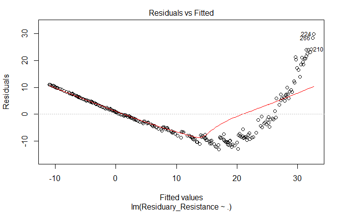

```r
plot(linear_model_y_hd,1)
```

```r
predict_values_yhd <- predict(linear_model_y_hd,test_y_hd, interval="prediction")
```

```r
head(predict_values_yhd[,1])
```

```
        5         8         9        12        15        22
 2.859396 12.235959 15.361480 24.738042 -9.489533 12.389113
```

```r
head(test_y_hd$Residuary_Resistance)
```

```
[1]  1.18  3.76  4.99 20.11  0.04  3.29
```

```r
residuals_yhd <- test_y_hd$Residuary_Resistance - predict_values_yhd[,1]
RSS_v <-sum(residuals_yhd^2)
TSS_v <-sum((test_y_hd$Residuary_Resistance-mean(test_y_hd$Residuary_Resistance))^2)
```

```r
cat("Sum of residual square error of the test dataset is(RSS): ",sum(residuals_yhd^2))
```

```
Sum of residual square error of the test dataset is(RSS):  4051.87
```

```r
cat("Mean of residual square error of the test dataset is: ",mean(residuals_yhd^2))
```

```
Mean of residual square error of the test dataset is:  67.53116
```

```r
cat("Root mean of residual square error of the test dataset is: ",sqrt(mean(residuals_yhd^2)))
```

```
Root mean of residual square error of the test dataset is:  8.217735
```

```r
cat("Total sum of residual square error of the test dataset is(TSS): ",sum((test_y_hd$Residuary_Resistance-mean(test_y_hd$Residuary_Resistance))^2))
```

```
Total sum of residual square error of the test dataset is(TSS):  10178.32
```

```r
cat("The R squared value of the test data is: ",(1-(RSS_v/TSS_v)))
```

```
The R squared value of the test data is:  0.6019119
```

```r
cat("Residual standard error of the test data is: ",sqrt(RSS_v/53))
```

```
Residual standard error of the test data is:  8.74359
```

#### Bootstrap Model:

```r
fit_ctrl_yhd <- trainControl(method = "boot", number = 1000)
```

```r
fit_tr <- train(Residuary_Resistance~.,data=train_y_hd,trControl=fit_ctrl_yhd,method="glmboost")
fit_tr
```

```
Boosted Generalized Linear Model

248 samples
  6 predictor

No pre-processing
Resampling: Bootstrapped (1000 reps)
Summary of sample sizes: 248, 248, 248, 248, 248, 248, ...
Resampling results across tuning parameters:

  mstop  RMSE      Rsquared   MAE
   50    9.276746  0.6573453  7.380134
  100    9.344872  0.6523336  7.492411
  150    9.368110  0.6507671  7.523248

Tuning parameter 'prune' was held constant at a value of no
RMSE was used to select the optimal model using the smallest value.
The final values used for the model were mstop = 50 and prune = no.
```

```r
names(fit_tr)
```

```
 [1] "method"       "modelInfo"    "modelType"    "results"      "pred"         "bestTune"
 [7] "call"         "dots"         "metric"       "control"      "finalModel"   "preProcess"
[13] "trainingData" "resample"     "resampledCM"  "perfNames"    "maximize"     "yLimits"
[19] "times"        "levels"       "terms"        "coefnames"    "xlevels"
```

```r
cat("Training RMSE Resampling results of bootstrap Linear Model: ",fit_tr$results$RMSE)
```

```
Training RMSE Resampling results of bootstrap Linear Model:  9.276746 9.344872 9.36811
```

```r
cat("Training Rsquared Resampling results of bootstrap Linear Model: ",fit_tr$results$Rsquared)
```

```
Training Rsquared Resampling results of bootstrap Linear Model:  0.6573453 0.6523336 0.6507671
```

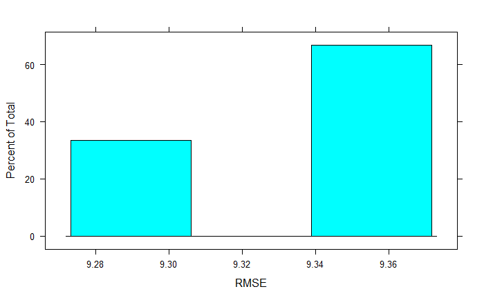

```r
histogram(fit_tr$results$RMSE,xlab="RMSE")
```

```r
cat("Mean RMSE for the model fit: ",mean(fit_tr$results$RMSE))
```

```
Mean RMSE for the model fit:  9.32991
```

```r
cat("Mean Rsquared for the model fit: ",mean(fit_tr$results$Rsquared))
```

```
Mean Rsquared for the model fit:  0.653482
```

#### Model Comparison:

From the above observations we can observe that the Rsquared value and RMSE of the train data using linear model is 0.664 and 9.0298.On the other hand, The Rsquared and RMSE of the train data using Bootstrap model is 0.6535 and 9.33.We can conclude that Linear model did slightly better than the bootstrap model on the train dataset as it has higher Rsquared and low RMSE than the bootstrap model.To note that both the model values are similar with slight variations.

```r
Activity_test_yhd <- predict(fit_tr, newdata = test_y_hd)
head(test_y_hd$Residuary_Resistance)
```

```
[1]  1.18  3.76  4.99 20.11  0.04  3.29
```

```r
head(Activity_test_yhd)
```

```
          [,1]
[1,]  2.973120
[2,] 12.178380
[3,] 15.246800
[4,] 24.452061
[5,] -8.979856
[6,] 12.499084
```

```r
res_yhd_bs <- (Activity_test_yhd-test_y_hd$Residuary_Resistance)
```

```r
mse_yhd_bs <- mean(res_yhd_bs^2)
cat("MSE of the test data using bootstrap model: ",mse_yhd_bs)
```

```
MSE of the test data using bootstrap model:  65.78458
```

```r
cat("RMSE of the test data using bootstrap model: ",sqrt(mse_yhd_bs))
```

```
RMSE of the test data using bootstrap model:  8.110769
```

```r
RSS_v_boot <-sum(res_yhd_bs^2)
TSS_v_boot <-sum((test_y_hd$Residuary_Resistance-mean(test_y_hd$Residuary_Resistance))^2)
cat("Rsquared value of the test data using bootstrap model: ",(1-(RSS_v_boot/TSS_v_boot)))
```

```
Rsquared value of the test data using bootstrap model:  0.6122078
```

From the above observations we can observe that the Rsquared value and RMSE of the test data(out of sample observations) using linear model is 0.602 and 8.218.On the other hand, The Rsquared and RMSE of the test data using Bootstrap model is 0.6122 and 8.11.We can conclude that bootstrap model did slightly better than the linear model on the test dataset as it has higher Rsquared and low RMSE than the linear model.

## Problem 2.2

### German Credit Dataset

```r
url_German_credit <- "https://archive.ics.uci.edu/ml/machine-learning-databases/statlog/german/german.data-numeric"
data_german_credit <- read.csv(url_German_credit,header = F,sep="")
```

```r
str(data_german_credit)
```

```
'data.frame':   1000 obs. of  25 variables:
 $ V1 : int  1 2 4 1 1 4 4 2 4 2 ...
 $ V2 : int  6 48 12 42 24 36 24 36 12 30 ...
 $ V3 : int  4 2 4 2 3 2 2 2 2 4 ...
 $ V4 : int  12 60 21 79 49 91 28 69 31 52 ...
 $ V5 : int  5 1 1 1 1 5 3 1 4 1 ...
 $ V6 : int  5 3 4 4 3 3 5 3 4 1 ...
 $ V7 : int  3 2 3 3 3 3 3 3 1 4 ...
 $ V8 : int  4 2 3 4 4 4 4 2 4 2 ...
 $ V9 : int  1 1 1 2 4 4 2 3 1 3 ...
 $ V10: int  67 22 49 45 53 35 53 35 61 28 ...
 $ V11: int  3 3 3 3 3 3 3 3 3 3 ...
 $ V12: int  2 1 1 1 2 1 1 1 1 2 ...
 $ V13: int  1 1 2 2 2 2 1 1 1 1 ...
 $ V14: int  2 1 1 1 1 2 1 2 1 1 ...
 $ V15: int  1 1 1 1 1 1 1 1 1 1 ...
 $ V16: int  0 0 0 0 1 0 0 0 0 1 ...
 $ V17: int  0 0 0 0 0 0 0 1 0 0 ...
 $ V18: int  1 1 1 0 1 1 1 1 1 1 ...
 $ V19: int  0 0 0 0 0 0 0 0 0 0 ...
 $ V20: int  0 0 0 0 0 0 0 1 0 0 ...
 $ V21: int  1 1 1 0 0 0 1 0 1 1 ...
 $ V22: int  0 0 0 0 0 0 0 0 0 0 ...
 $ V23: int  0 0 1 0 0 1 0 0 1 0 ...
 $ V24: int  1 1 0 1 1 0 1 0 0 0 ...
 $ V25: int  1 2 1 1 2 1 1 1 1 2 ...
```

```r
set.seed(100)
index_german_credit <- createDataPartition(data_german_credit$V25, p = 0.8,list = F)
train_german_credit <- data_german_credit[index_german_credit,]
test_german_credit <- data_german_credit[-index_german_credit,]
```

```r
logistic_german_credit <- glm(V25~V1+V2+V3+V5+V11+V15+V16+V17+V18+V19,data = train_german_credit)
summary(logistic_german_credit)
```

```
Call:
glm(formula = V25 ~ V1 + V2 + V3 + V5 + V11 + V15 + V16 + V17 +
    V18 + V19, data = train_german_credit)

Deviance Residuals:
    Min       1Q   Median       3Q      Max
-0.8626  -0.3160  -0.1097   0.3850   1.0932

Coefficients:
             Estimate Std. Error t value Pr(>|t|)
(Intercept)  1.693520   0.132319  12.799  < 2e-16 ***
V1          -0.093967   0.012259  -7.665 5.24e-14 ***
V2           0.008583   0.001264   6.793 2.17e-11 ***
V3          -0.075268   0.014040  -5.361 1.09e-07 ***
V5          -0.031298   0.009585  -3.265  0.00114 **
V11         -0.057086   0.020835  -2.740  0.00629 **
V15         -0.111436   0.082043  -1.358  0.17477
V16          0.093088   0.035763   2.603  0.00942 **
V17         -0.085768   0.051809  -1.655  0.09823 .
V18          0.211316   0.070531   2.996  0.00282 **
V19          0.273880   0.096198   2.847  0.00453 **
---
Signif. codes:  0 *** 0.001 ** 0.01 * 0.05 . 0.1   1

(Dispersion parameter for gaussian family taken to be 0.1703432)

    Null deviance: 174.8  on 799  degrees of freedom
Residual deviance: 134.4  on 789  degrees of freedom
AIC: 867.27

Number of Fisher Scoring iterations: 2
```

```r
names(logistic_german_credit)
```

```
 [1] "coefficients"      "residuals"         "fitted.values"     "effects"
 [5] "R"                 "rank"              "qr"                "family"
 [9] "linear.predictors" "deviance"          "aic"               "null.deviance"
[13] "iter"              "weights"           "prior.weights"     "df.residual"
[17] "df.null"           "y"                 "converged"         "boundary"
[21] "model"             "call"              "formula"           "terms"
[25] "data"              "offset"            "control"           "method"
[29] "contrasts"         "xlevels"
```

```r
RSquared_german_ct <- 1-(logistic_german_credit$deviance/logistic_german_credit$null.deviance)
residuals_german_credit <- logistic_german_credit$residuals
MSE_german_credit <- mean(residuals_german_credit^2)
RMSE_german_credit <- sqrt(MSE_german_credit)
```

```r
cat("The R squared value of the model using train data is: ",RSquared_german_ct)
```

```
The R squared value of the model using train data is:  0.2310948
```

```r
cat("Mean of residual square error using train dataset is: ",MSE_german_credit)
```

```
Mean of residual square error using train dataset is:  0.168001
```

```r
cat("Root Mean of residual square error using train dataset is: ",sqrt(MSE_german_credit))
```

```
Root Mean of residual square error using train dataset is:  0.4098792
```

```r
cat("Sum of residual square error using train dataset is: ",sum(residuals_german_credit^2))
```

```
Sum of residual square error using train dataset is:  134.4008
```

```r
cat("Residual standard error using train dataset is: ",sqrt(sum(residuals_german_credit^2)/logistic_german_credit$df.residual))
```

```
Residual standard error using train dataset is:  0.4127266
```

#### Prediction on the out of sample observation

```r
predict_german_ct_tt <- predict(logistic_german_credit,test_german_credit, interval="prediction")
residual_gc_test_lin <- predict_german_ct_tt - test_german_credit$V25
MSE_gc_test_lin <- mean(residual_gc_test_lin^2)
RMSE_gc_test_lin <- sqrt(MSE_gc_test_lin)
RSS_gc_test_lin <- sum(residual_gc_test_lin^2)
TSS_gc_test_lin <- sum((test_german_credit$V25-mean(test_german_credit$V25))^2)
```

```r
cat("The R squared value of the model using test data is: ",1-(RSS_gc_test_lin/TSS_gc_test_lin))
```

```
The R squared value of the model using test data is:  0.1588393
```

```r
cat("Mean of residual square error using test dataset is: ",MSE_gc_test_lin)
```

```
Mean of residual square error using test dataset is:  0.1395486
```

```r
cat("Root Mean of residual square error using test dataset is: ",RMSE_gc_test_lin)
```

```
Root Mean of residual square error using test dataset is:  0.373562
```

```r
cat("Sum of residual square error using test dataset is: ",RSS_gc_test_lin)
```

```
Sum of residual square error using test dataset is:  27.90971
```

```r
cat("Residual standard error using test dataset is: ",sqrt(RSS_gc_test_lin/189))
```

```
Residual standard error using test dataset is:  0.3842791
```

#### K-fold(10) cross validation:

```r
K_10_german_ct <- trainControl(method="cv", number=10)
Model_K_10_gt <- train(V25~V1+V2+V3+V5+V11+V15+V16+V17+V18+V19, data= train_german_credit, trControl=K_10_german_ct, method="glm")
```

```
You are trying to do regression and your outcome only has two possible values Are you trying to do classification? If so, use a 2 level factor as your outcome column.
```

```r
Model_K_10_gt
```

```
Generalized Linear Model

800 samples
 10 predictor

No pre-processing
Resampling: Cross-Validated (10 fold)
Summary of sample sizes: 720, 720, 720, 720, 720, 720, ...
Resampling results:

  RMSE       Rsquared   MAE
  0.4142585  0.2179942  0.3501096
```

```r
names(Model_K_10_gt)
```

```
 [1] "method"       "modelInfo"    "modelType"    "results"      "pred"         "bestTune"
 [7] "call"         "dots"         "metric"       "control"      "finalModel"   "preProcess"
[13] "trainingData" "resample"     "resampledCM"  "perfNames"    "maximize"     "yLimits"
[19] "times"        "levels"       "terms"        "coefnames"    "xlevels"
```

```r
cat("Mean RMSE for the K-fold(10) cross validation: ",mean(Model_K_10_gt$resample$RMSE))
```

```
Mean RMSE for the K-fold(10) cross validation:  0.4142585
```

```r
cat("Mean Rsquare for the K-fold(10) cross validation: ",mean(Model_K_10_gt$resample$Rsquared))
```

```
Mean Rsquare for the K-fold(10) cross validation:  0.2179942
```

```r
pct_k10_tst <- predict(Model_K_10_gt, newdata = test_german_credit)
res_k10_tst <- pct_k10_tst - test_german_credit$V25
RSS_K10_tst <- sum(res_k10_tst^2)
TSS_K10_tst <- sum((test_german_credit$V25 - mean(test_german_credit$V25))^2)
```

```r
cat("Mean of residual square error of the K10 cv model using test dataset is: ",mean(res_k10_tst^2))
```

```
Mean of residual square error of the K10 cv model using test dataset is:  0.1395486
```

```r
cat("Root Mean of residual square error of the K10 cv model using test dataset is: ",sqrt(mean(res_k10_tst^2)))
```

```
Root Mean of residual square error of the K10 cv model using test dataset is:  0.373562
```

```r
cat("Sum of residual square error using of the K10 cv model test dataset is: ",sum(res_k10_tst^2))
```

```
Sum of residual square error using of the K10 cv model test dataset is:  27.90971
```

```r
cat("The R squared value of the K10 cv model using testset data is: ",1-(RSS_K10_tst/TSS_K10_tst))
```

```
The R squared value of the K10 cv model using testset data is:  0.1588393
```

## Problem 2.3

### Mtcars Dataset

#### Linear Model:

```r
data(mtcars)
head(mtcars)
```

|  | mpg | cyl | disp | hp | drat | wt | qsec | vs | am | gear | carb |
| --- | --- | --- | --- | --- | --- | --- | --- | --- | --- | --- | --- |
| Mazda RX4 | 21.0 | 6 | 160 | 110 | 3.90 | 2.620 | 16.46 | 0 | 1 | 4 | 4 |
| Mazda RX4 Wag | 21.0 | 6 | 160 | 110 | 3.90 | 2.875 | 17.02 | 0 | 1 | 4 | 4 |
| Datsun 710 | 22.8 | 4 | 108 | 93 | 3.85 | 2.320 | 18.61 | 1 | 1 | 4 | 1 |
| Hornet 4 Drive | 21.4 | 6 | 258 | 110 | 3.08 | 3.215 | 19.44 | 1 | 0 | 3 | 1 |
| Hornet Sportabout | 18.7 | 8 | 360 | 175 | 3.15 | 3.440 | 17.02 | 0 | 0 | 3 | 2 |
| Valiant | 18.1 | 6 | 225 | 105 | 2.76 | 3.460 | 20.22 | 1 | 0 | 3 | 1 |

```r
str(mtcars)
```

```
'data.frame':   32 obs. of  11 variables:
 $ mpg : num  21 21 22.8 21.4 18.7 18.1 14.3 24.4 22.8 19.2 ...
 $ cyl : num  6 6 4 6 8 6 8 4 4 6 ...
 $ disp: num  160 160 108 258 360 ...
 $ hp  : num  110 110 93 110 175 105 245 62 95 123 ...
 $ drat: num  3.9 3.9 3.85 3.08 3.15 2.76 3.21 3.69 3.92 3.92 ...
 $ wt  : num  2.62 2.88 2.32 3.21 3.44 ...
 $ qsec: num  16.5 17 18.6 19.4 17 ...
 $ vs  : num  0 0 1 1 0 1 0 1 1 1 ...
 $ am  : num  1 1 1 0 0 0 0 0 0 0 ...
 $ gear: num  4 4 4 3 3 3 3 4 4 4 ...
 $ carb: num  4 4 1 1 2 1 4 2 2 4 ...
```

```r
set.seed(100)
index_mtcars <- createDataPartition(mtcars$mpg, p = 0.8,list = F)
train_mtcars<- mtcars[index_mtcars,]
test_mtcars <- mtcars[-index_mtcars,]
mtcars$am <- factor(mtcars$am)
```

```r
lm_mtcars <- lm(mpg~.,data=train_mtcars)
summary(lm_mtcars)
```

```
Call:
lm(formula = mpg ~ ., data = train_mtcars)

Residuals:
    Min      1Q  Median      3Q     Max
-2.7521 -1.7131 -0.3609  0.9468  4.6947

Coefficients:
            Estimate Std. Error t value Pr(>|t|)
(Intercept)  6.20861   19.06768   0.326   0.7487
cyl          0.38036    1.02657   0.371   0.7156
disp         0.01294    0.01820   0.711   0.4867
hp          -0.03073    0.02241  -1.371   0.1882
drat         1.12489    1.76904   0.636   0.5333
wt          -4.59168    2.09849  -2.188   0.0429 *
qsec         1.20694    0.72949   1.654   0.1164
vs          -0.44236    2.09164  -0.211   0.8350
am           2.94238    2.06292   1.426   0.1719
gear         0.05426    1.54163   0.035   0.9723
carb         0.28072    0.85332   0.329   0.7462
---
Signif. codes:  0 *** 0.001 ** 0.01 * 0.05 . 0.1   1

Residual standard error: 2.526 on 17 degrees of freedom
Multiple R-squared:  0.8901,    Adjusted R-squared:  0.8255
F-statistic: 13.77 on 10 and 17 DF,  p-value: 2.788e-06
```

```r
summary_mtcars <-summary(lm_mtcars)
```

```r
cat("The R squared value of the model using train data is: ",summary_mtcars$r.squared)
```

```
The R squared value of the model using train data is:  0.8901033
```

```r
cat("The adjusted R squared value of the model using train data is: ",summary_mtcars$adj.r.squared)
```

```
The adjusted R squared value of the model using train data is:  0.8254581
```

```r
cat("Mean of residual square error using train dataset is: ",mean(summary_mtcars$residuals^2))
```

```
Mean of residual square error using train dataset is:  3.874807
```

```r
cat("Sum of residual square error using train dataset is: ",sum(summary_mtcars$residuals^2))
```

```
Sum of residual square error using train dataset is:  108.4946
```

```r
cat("Residual standard error using train dataset is: ",sqrt(sum(summary_mtcars$residuals^2)/17))
```

```
Residual standard error using train dataset is:  2.526269
```

```r
cat("F-statistic value using the train dataset with 10 predictors and 17 degrees of freedom is: ",summary_mtcars$fstatistic)
```

```
F-statistic value using the train dataset with 10 predictors and 17 degrees of freedom is:  13.76907 10 17
```

```r
names(lm_mtcars)
```

```
 [1] "coefficients"  "residuals"     "effects"       "rank"          "fitted.values"
 [6] "assign"        "qr"            "df.residual"   "xlevels"       "call"
[11] "terms"         "model"
```

```r
cat("Associated coefficient value for the feature wt is: ",lm_mtcars$coefficients[6])
```

```
Associated coefficient value for the feature wt is:  -4.591679
```

```r
cat("Associated coefficient value for the feature hp is: ",lm_mtcars$coefficients[4])
```

```
Associated coefficient value for the feature hp is:  -0.03072951
```

#### Prediction on the out of sample observations

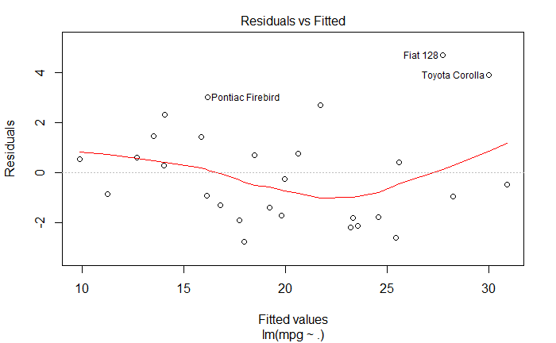

```r
plot(lm_mtcars,1)
```

```r
predicted_values_linear_mtcars <- predict(lm_mtcars,test_mtcars, interval="prediction")
```

```r
predicted_values_linear_mtcars
```

```
                       fit       lwr      upr
Mazda RX4         23.68686 17.287434 30.08629
Hornet Sportabout 17.54781 11.560707 23.53492
Chrysler Imperial  9.28021  2.723785 15.83663
Lotus Europa      26.51221 19.265123 33.75929
```

```r
test_mtcars$mpg
```

```
[1] 21.0 18.7 14.7 30.4
```

```r
residuals_linear_mtcars <- test_mtcars$mpg - predicted_values_linear_mtcars[,1]
cat("Mean of residual square error of the test dataset using linear model is: ",mean(residuals_linear_mtcars^2))
```

```
Mean of residual square error of the test dataset using linear model is:  13.25895
```

#### Ridge Regression:

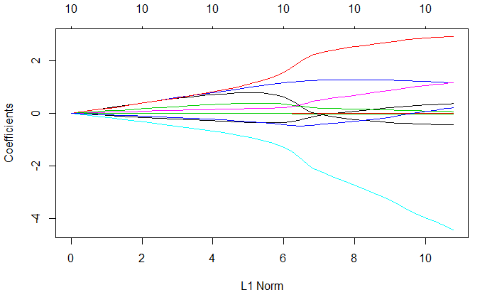

```r
grid_ridge=10^seq(10,-2,length=100)
x_ridge=model.matrix(mpg~.,mtcars)[,-1]
y_ridge=mtcars$mpg
ridge_mtcars=glmnet(x_ridge[index_mtcars,],y_ridge[index_mtcars],alpha=0,lambda=grid_ridge,thresh=1e-12)
plot(ridge_mtcars)
```

```r
ridge_mtcars_min=cv.glmnet(x_ridge[index_mtcars,],y_ridge[index_mtcars],alpha=0,parallel=TRUE)
```

```
Option grouped=FALSE enforced in cv.glmnet, since < 3 observations per fold
```

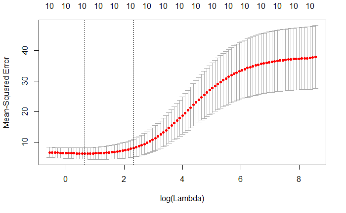

```r
plot(ridge_mtcars_min)
```

```r
names(ridge_mtcars_min)
```

```
 [1] "lambda"     "cvm"        "cvsd"       "cvup"       "cvlo"       "nzero"      "name"
 [8] "glmnet.fit" "lambda.min" "lambda.1se"
```

```r
cat("The minimum value obtained for lambda is: ",ridge_mtcars_min$lambda.min)
```

```
The minimum value obtained for lambda is:  1.914846
```

```r
ridge_mc_predict=predict(ridge_mtcars,s=ridge_mtcars_min$lambda.min,newx=x_ridge[-index_mtcars,])
ridge_mc_predict
```

```
                         1
Mazda RX4         22.13626
Hornet Sportabout 16.29147
Chrysler Imperial 11.40459
Lotus Europa      26.39666
```

```r
test_mtcars[,1]
```

```
[1] 21.0 18.7 14.7 30.4
```

```r
cat("Out of sample test MSE using ridge regression is : ",mean((ridge_mc_predict-test_mtcars[,1])^2))
```

```
Out of sample test MSE using ridge regression is :  8.494636
```

```r
out_ridge=glmnet(x_ridge,y_ridge,alpha=0)
redge.coef=predict(out_ridge,type="coefficients",s=ridge_mtcars_min$lambda.min)
redge.coef
```

```
11 x 1 sparse Matrix of class "dgCMatrix"
                      1
(Intercept) 21.24571880
cyl         -0.35617789
disp        -0.00489582
hp          -0.01195576
drat         1.04437694
wt          -1.35319063
qsec         0.17537646
vs           0.70847877
am1          1.74497910
gear         0.55560345
carb        -0.59321567
```

```r
lm_mtcars$coefficients
```

```
(Intercept)         cyl        disp          hp        drat          wt        qsec          vs
 6.20861262  0.38035730  0.01294339 -0.03072951  1.12488780 -4.59167882  1.20694177 -0.44236247
         am        gear        carb
 2.94237708  0.05426154  0.28071512
```

MSE of the test data using the reidge regression model is 8.49 and the MSE of the test data using linear model is 13.259. From this result we can say that the ridge regression model performed better than Linear model since it has low MSE.The coefficients obtained using Ridge Regression is different to Coefficients obtained from the Linear Regression model but ridge regression model did well on out of sample observations than the linear model.Ridge Regression performed shrinkage as the coefficients are close to zero.

## Problem 2.4

### Swiss Dataset

#### Linear Model:

```r
data("swiss")
head(swiss)
```

|  | Fertility | Agriculture | Examination | Education | Catholic | Infant.Mortality |
| --- | --- | --- | --- | --- | --- | --- |
| Courtelary | 80.2 | 17.0 | 15 | 12 | 9.96 | 22.2 |
| Delemont | 83.1 | 45.1 | 6 | 9 | 84.84 | 22.2 |
| Franches-Mnt | 92.5 | 39.7 | 5 | 5 | 93.40 | 20.2 |
| Moutier | 85.8 | 36.5 | 12 | 7 | 33.77 | 20.3 |
| Neuveville | 76.9 | 43.5 | 17 | 15 | 5.16 | 20.6 |
| Porrentruy | 76.1 | 35.3 | 9 | 7 | 90.57 | 26.6 |

```r
str(swiss)
```

```
'data.frame':   47 obs. of  6 variables:
 $ Fertility       : num  80.2 83.1 92.5 85.8 76.9 76.1 83.8 92.4 82.4 82.9 ...
 $ Agriculture     : num  17 45.1 39.7 36.5 43.5 35.3 70.2 67.8 53.3 45.2 ...
 $ Examination     : int  15 6 5 12 17 9 16 14 12 16 ...
 $ Education       : int  12 9 5 7 15 7 7 8 7 13 ...
 $ Catholic        : num  9.96 84.84 93.4 33.77 5.16 ...
 $ Infant.Mortality: num  22.2 22.2 20.2 20.3 20.6 26.6 23.6 24.9 21 24.4 ...
```

```r
set.seed(1)
index_swiss <- createDataPartition(swiss$Fertility, p = 0.8,list = F)
train_swiss <- swiss[index_swiss,]
test_swiss <- swiss[-index_swiss,]
lm_swiss <- lm(Fertility~.,data=train_swiss)
summary(lm_swiss)
```

```
Call:
lm(formula = Fertility ~ ., data = train_swiss)

Residuals:
     Min       1Q   Median       3Q      Max
-17.1488  -4.2579  -0.2605   4.7211  13.9012

Coefficients:
                 Estimate Std. Error t value Pr(>|t|)
(Intercept)      67.90877   11.56769   5.871 1.41e-06 ***
Agriculture      -0.14628    0.07809  -1.873  0.06993 .
Examination      -0.38965    0.28766  -1.355  0.18477
Education        -0.71321    0.21871  -3.261  0.00258 **
Catholic          0.09296    0.04338   2.143  0.03959 *
Infant.Mortality  1.03237    0.42640   2.421  0.02113 *
---
Signif. codes:  0 *** 0.001 ** 0.01 * 0.05 . 0.1   1

Residual standard error: 7.518 on 33 degrees of freedom
Multiple R-squared:  0.6913,    Adjusted R-squared:  0.6445
F-statistic: 14.78 on 5 and 33 DF,  p-value: 1.268e-07
```

```r
summary_swiss <-summary(lm_swiss)
```

```r
cat("The R squared value of the model using train data is: ",summary_swiss$r.squared)
```

```
The R squared value of the model using train data is:  0.6913152
```

```r
cat("The adjusted R squared value of the model using train data is: ",summary_swiss$adj.r.squared)
```

```
The adjusted R squared value of the model using train data is:  0.6445447
```

```r
cat("Mean of residual square error using train dataset is: ",mean(summary_swiss$residuals^2))
```

```
Mean of residual square error using train dataset is:  47.81932
```

```r
cat("Sum of residual square error using train dataset is: ",sum(summary_swiss$residuals^2))
```

```
Sum of residual square error using train dataset is:  1864.953
```

```r
cat("Residual standard error using train dataset is: ",sqrt(sum(summary_swiss$residuals^2)/33))
```

```
Residual standard error using train dataset is:  7.517562
```

```r
cat("F-statistic value using the train dataset with 5 predictors and 33 degrees of freedom is: ",summary_swiss$fstatistic)
```

```
F-statistic value using the train dataset with 5 predictors and 33 degrees of freedom is:  14.78103 5 33
```

Based on the summary of the linear model using swiss dataset we can observe that Predictors Education,Catholic and Infant.Mortality have high T-value(away from 0) corresponding to other predictors.

```r
names(lm_swiss)
```

```
 [1] "coefficients"  "residuals"     "effects"       "rank"          "fitted.values"
 [6] "assign"        "qr"            "df.residual"   "xlevels"       "call"
[11] "terms"         "model"
```

```r
cat("Associated coefficient value for the feature Education is: ",lm_swiss$coefficients[4])
```

```
Associated coefficient value for the feature Education is:  -0.7132132
```

```r
cat("Associated coefficient value for the feature Catholic is: ",lm_swiss$coefficients[5])
```

```
Associated coefficient value for the feature Catholic is:  0.09296356
```

```r
cat("Associated coefficient value for the feature Infant.Mortality is: ",lm_swiss$coefficients[6])
```

```
Associated coefficient value for the feature Infant.Mortality is:  1.032374
```

#### Prediction on the out of sample observations

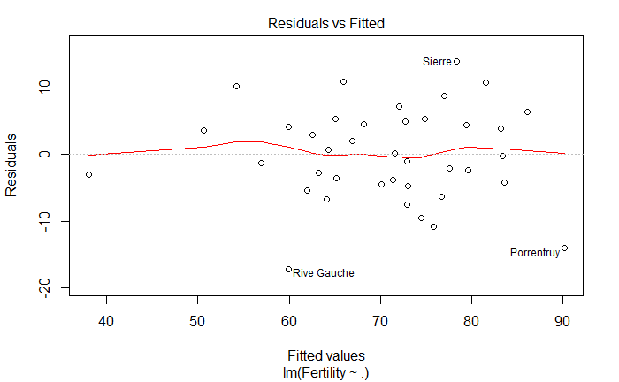

```r
plot(lm_swiss,1)
```

```r
predicted_values_linear <- predict(lm_swiss,test_swiss, interval="prediction")
```

```r
predicted_values_linear
```

```
                 fit      lwr      upr
Gruyere     81.20345 65.16064 97.24626
Sarine      79.47578 63.19959 95.75196
Aubonne     67.51676 51.33532 83.69820
Oron        74.00770 57.68975 90.32564
Payerne     73.30590 56.73602 89.87578
Vevey       63.98900 48.24421 79.73379
Entremont   78.19048 62.06426 94.31671
Rive Droite 57.65200 40.34086 74.96313
```

```r
test_swiss$Fertility
```

```
[1] 82.4 82.9 66.9 72.5 74.2 58.3 69.3 44.7
```

```r
residuals_linear <- test_swiss$Fertility - predicted_values_linear[,1]
cat("Mean of residual square error of the test dataset using linear model is: ",mean(residuals_linear^2))
```

```
Mean of residual square error of the test dataset using linear model is:  36.97121
```

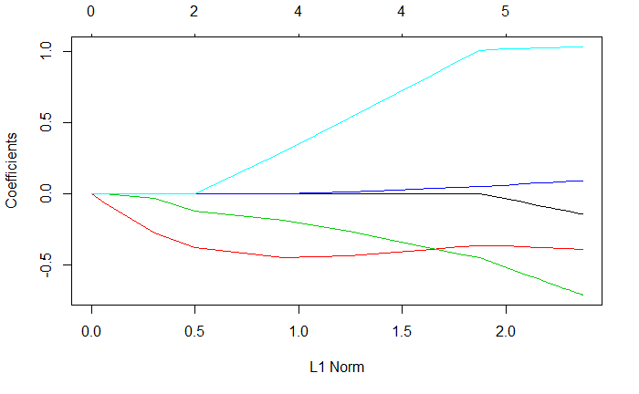

```r
grid=10^seq(10,-2,length=100)
x=model.matrix(Fertility~.,swiss)[,-1]
y=swiss$Fertility
lasso_swiss=glmnet(x[index_swiss,],y[index_swiss],alpha=1,lambda=grid)
plot(lasso_swiss)
```

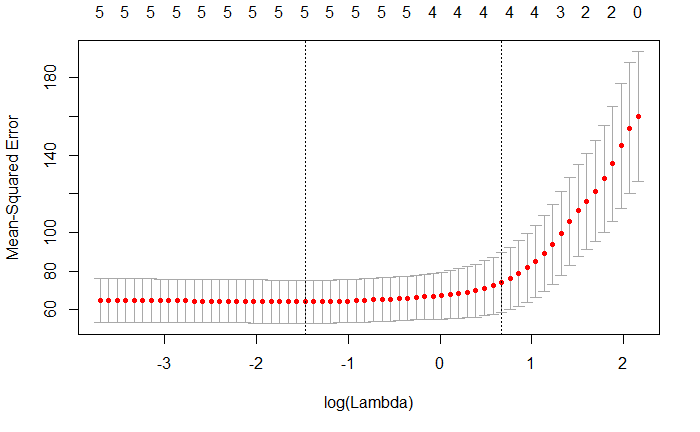

```r
lasso_swiss_min=cv.glmnet(x[index_swiss,],y[index_swiss],alpha=1,parallel=TRUE)
plot(lasso_swiss_min)
```

```r
names(lasso_swiss_min)
```

```
 [1] "lambda"     "cvm"        "cvsd"       "cvup"       "cvlo"       "nzero"      "name"
 [8] "glmnet.fit" "lambda.min" "lambda.1se"
```

```r
cat("The minimum value obtained for lambda is: ",lasso_swiss_min$lambda.min)
```

```
The minimum value obtained for lambda is:  0.2298239
```

```r
lasso_predict=predict(lasso_swiss,s=lasso_swiss_min$lambda.min,newx=x[-index_swiss,])
lasso_predict
```

```
                   1
Gruyere     80.38198
Sarine      78.83699
Aubonne     68.37063
Oron        74.55955
Payerne     73.79898
Vevey       63.96224
Entremont   78.49404
Rive Droite 58.69686
```

```r
test_swiss[,1]
```

```
[1] 82.4 82.9 66.9 72.5 74.2 58.3 69.3 44.7
```

```r
cat("Out of sample test MSE using Lasso regression is : ",mean((lasso_predict-test_swiss[,1])^2))
```

```
Out of sample test MSE using Lasso regression is :  42.45615
```

```r
out=glmnet(x,y,alpha=1,lambda=grid)
lasso.coef=predict(out,type="coefficients",s=lasso_swiss_min$lambda.min)[1:6,]
lasso.coef
```

```
     (Intercept)      Agriculture      Examination        Education         Catholic
     64.22815697      -0.13133459      -0.22995656      -0.80773179       0.09504967
Infant.Mortality
      1.06890747
```

```r
lm_swiss$coefficients
```

```
     (Intercept)      Agriculture      Examination        Education         Catholic
     67.90877025      -0.14627909      -0.38964642      -0.71321323       0.09296356
Infant.Mortality
      1.03237403
```